# ML_Py_Lab05_Ensemble3_grbt_v11_2610

> 🛠️ **2026.10 수정본 (v11)** — 원본: `ML_Py_Lab05_Ensemble3_grbt.ipynb`
> - 윈도우 전용 폰트 경로(`C:/Windows/Fonts/...`) 대신 `koreanize-matplotlib`로 한글 폰트를 잡도록 바꿨어요. 이제 코랩·윈도우·맥 어디서나 같은 셀로 한글이 보여요. (Python 3.12부터 빠진 `distutils` 때문에 생기는 오류를 막으려고 `setuptools`도 함께 설치해요.)

## Review

```
(1) 지도학습에는 분류와 회귀가 있다.
(2) 분류에는 이진 분류(binary classification)와 다중 분류가 있다.
(3) 이진 분류는 양성(positive)과 음성(negative)가 있다.
(4) 모델을 만들때는 가능한 일반화(generalization)되도록 해야 한다.
    일반화란 만들어진 모델이 새로운 데이터에 정확하게 예측할 수 있다면 우리는
    훈련세트에서 테스트 세트로 일반화(generalization)되었다고 한다.
(5) 과적합(overfitting)(과대적합) - 모델이 훈련 세트의 각 샘플에 너무 가깝게 맞춰져서
    새로운 데이터가 일반화 되기 어려울 때 나타나는 현상.
    과소적합(underfitting) - 너무 간단한 모델. 과적합과 반대.
    ==>  우리의 모델은 일반화 성능이 최대가 되는 최적점에 있는 모델
    ==> 데이터셋에 다양한 데이터 포인트가 많을 수록 과적합 없이 더 복잡한 모델을
        만들 수 있다. 데이터 셋이 많으면 많을 수록 더 다양한 데이터 포인터를 갖는다.
        정확도가 높은 복잡한 모델을 만들 수 있다.
```

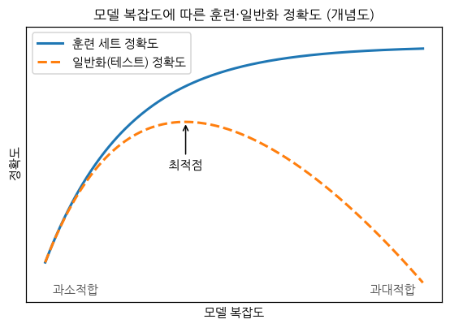

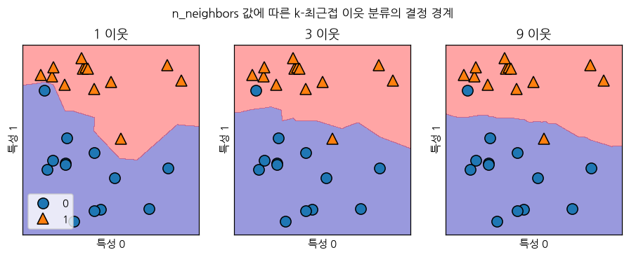

이웃이 하나일 때, 결정 경계가 훈련 데이터에 가깝게 따라간다. 이웃의 수를 늘릴수록 결정 경계는 더 부드러워진다. 부드러운 경계는 더 단순한 모델을 의미한다. 이웃을 적게 사용하면 모델의 복잡도는 높아지고, 많이 사용하면 복잡도는 낮아진다.

```
(1) 데이터셋을 훈련세트와 데이터 세트로 나누는 함수(      )
(2) Python에서의 Knn 모델의 이름
(3) reg = _____(n_neighbors=3)
(4) 모델을 reg 객체로 저장하고, 모델을 학습을 시킬 때 어떻게 할까?
(5) 예측은 어떤 메소드(함수)를 이용할까?
(6) _____ 메소드를 이용하여 모델을 평가할 수 있을까? 이 값이 반환하는 값은?
```

### 선형모델(linear Regression)

### 릿지회귀(Ridge Regression) - L2 규제(regularization)

#### 가중치의 절대값을 가능한 한 작게 만든다.(w의 모든 원소가 0에 가깝게 되길 원함.)

### 라쏘(Lasso Regression) - L1 규제(regularization)

#### L1규제의 결과로 라쏘를 사용할 때 어떤 계수는 정말 0이 된다.

### 보통은 릿지 회귀, 그러나 특성이 많고 그중 일부부만 중요하다면 Lasso가 좋을 수 있다.

## 그래디언트 부스팅(Gradient Boosting)

```
(가) 여러 개의 결정 트리를 묶어 강력한 모델을 만든다.
(나) 랜덤포레스트(random forest)와 달리 그래디언트 부스팅은 이전 트리의 오차를 보완하는 방식으로 순차적으로 트리를 만든다.
(다) 무작위성이 없다. 대신 강력한 사전 가지치기(pruning)이 사용.
     ---> 하나에서 다섯 정도의 깊지 않은 트리를 사용. 메모리를 적게 사용하고 예측도 빠르다.
     ---> 얕은 트리 같은 간단한 모델(약한 학습기 - weak learner이라한다.)을 많이 연결한다.
(라) 각각의 트리는 일부에 대해서만 예측을 잘 수행할 수 있어, 트리가 많이 추가될수록 성능이 좋아진다.
(마) 랜덤 포레스트보다는 매개 변수 설정에 조금 더 민감하지만 잘 조정하면 더 높은 정확도를 제공한다.
(바) 그래디언트 부스팅에서 중요한 매개변수는 이전 트리의 오차를 얼마나 강하게 보정할 것인지 제어하는 learning_rate이다.
(사) n_estimators 값을 더 키우면 앙상블에 트리가 더 많이 추가되어 모델의 복잡도가 커지고 훈련 세트에서의 실수를 바로잡을 기회가 더 많아짐.
```

```python
from sklearn.model_selection import train_test_split
from sklearn.datasets import load_breast_cancer
import matplotlib.pyplot as plt
import numpy as np
%matplotlib inline

def plot_feature_importances_cancer(model):
    n_features = cancer.data.shape[1]
    plt.barh(range(n_features), model.feature_importances_, align='center')
    plt.yticks(np.arange(n_features), cancer.feature_names)
    plt.xlabel("특성 중요도")
    plt.ylabel("특성")
    plt.ylim(-1, n_features)
```

```python
### 한글
import matplotlib
# 한글 폰트 설정 (코랩·윈도우·맥 공통)  # 2026.10 수정: 윈도우 폰트 경로(C:/Windows/Fonts) 하드코딩 → koreanize-matplotlib로 교체
%pip install -q koreanize-matplotlib setuptools
import setuptools  # 2026.10 수정: Python 3.12+엔 distutils가 없어 koreanize-matplotlib가 실패 → setuptools가 대신 제공
import koreanize_matplotlib  # 나눔고딕을 matplotlib 기본 폰트로 등록
```

### 01 GradientBoosting 알고리즘

```
GradientBoostingClassifier는 기본값 깊이 3, 트리 100, 학습률 : 0.1 이용
```

```python
from sklearn.ensemble import GradientBoostingClassifier

cancer = load_breast_cancer()

X_train, X_test, y_train, y_test = train_test_split(cancer.data, cancer.target, random_state=0)
gbrt = GradientBoostingClassifier(random_state=0)
gbrt.fit(X_train, y_train)

print("훈련 세트 정확도: {:.3f}".format(gbrt.score(X_train, y_train)))
print("테스트 세트 정확도: {:.3f}".format(gbrt.score(X_test, y_test)))
```

```
훈련 세트 정확도: 1.000
테스트 세트 정확도: 0.965
```

## 02. 과적합(과대적합)- Overfitting 해결

```
트리의 최대 깊이를 줄여보자.
```

```python
gbrt = GradientBoostingClassifier(random_state=0, max_depth=1)
gbrt.fit(X_train, y_train)

print("훈련 세트 정확도: {:.3f}".format(gbrt.score(X_train, y_train)))
print("테스트 세트 정확도: {:.3f}".format(gbrt.score(X_test, y_test)))
```

```
훈련 세트 정확도: 0.991
테스트 세트 정확도: 0.972
```

### 트리의 학습률(learning_rate)를 조절해 보자.

```python
gbrt = GradientBoostingClassifier(random_state=0, learning_rate=0.01)
gbrt.fit(X_train, y_train)

print("훈련 세트 정확도: {:.3f}".format(gbrt.score(X_train, y_train)))
print("테스트 세트 정확도: {:.3f}".format(gbrt.score(X_test, y_test)))
```

```
훈련 세트 정확도: 0.988
테스트 세트 정확도: 0.958
```

## 모델의 특성(feature)의 중요도(importance) 이해

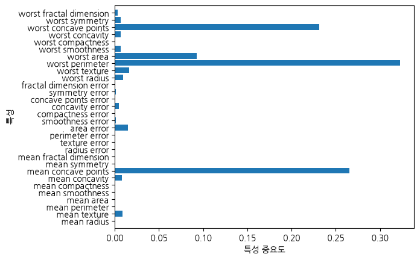

```python
gbrt = GradientBoostingClassifier(random_state=0, max_depth=1)
gbrt.fit(X_train, y_train)

plot_feature_importances_cancer(gbrt)
```

### Conclusion

[output not shown]

## 그래디언트 부스팅(gradient boosting) vs 랜덤 포레스트(random forest)

```
(가) 그래디언트 부스팅은 일부 특성을 완전히 무시한다.
(나) 랜덤 포레스트가 잘 작동하더라도 예측 시간이 중요하거나 머신러닝 모델의 마지막 성능까지 확인할 때 ,그래디언트 부스팅을 사용.
(다) 머신러닝 문제에 부스팅 적용시(xgboost)패키지와 파이썬 인터페이스 검토 필요
```

### 장단점과 매개변수

```
장점 :
    (가) 이진 특성이 연속적인 특성에서도 잘 동작함.
    (나) 특성의 스케일을 조정하지 않아도 된다.
단점 :
    (가) 매개변수를 잘 조정해야 하고 훈련 시간이 길다.
    (나) 고차원 데이터에서는 잘 작동하지 않음(트리 기반 모델의 특성)
```

### 중요 매개 변수

```
n_estimators, learning_rate
(1) learning_rate를 낮추면 비슷한 복잡도의 모델을 만들기 위해 더 많은 트리를 추가해야 함.
(2) n_estimators가 클수록 그래디언트 부스팅에서 n_estimators를 크게 하면 모델이 복잡해지고 과대적합될 가능성이 높다.
(3) 일반적인 관례 : 메모리 한도에서 n_estimators를 맞추고, 적절한 learning_rate를 찾는 것.
(4) max_depth, 부스팅 모델에서는 매우 작게 설정하고 트리의 깊이가 5보다 깊어지지 않게 한다.
```